# Report

## Setup

```python
import pickle
import pandas as pd
import altair as alt

from sklearn.metrics import r2_score
from sklearn.impute import SimpleImputer
from sklearn.metrics import mean_squared_error
from sklearn.metrics import mean_absolute_error
from sklearn.linear_model import LinearRegression, LogisticRegressionCV
from sklearn.model_selection import cross_val_score
from sklearn.model_selection import train_test_split
from sklearn.metrics import classification_report
from sklearn.metrics import ConfusionMatrixDisplay
from sklearn.metrics import RocCurveDisplay
from sklearn.metrics import roc_auc_score
from imblearn.over_sampling import RandomOverSampler
```

## 1 Introduction and data

### 1.1 Introduction and Motivation

For our project we have chosen a dataset about the release and establishment of the weevil Mecinus janthiniformis for biological control of Dalmatian toadflax in southern California.

Dalmatian toadflax was introduced to North America in the 1800s, presumably as ornamental plants and for use in fabrics and folk remedies. The species is now widespread in large parts of the USA and Canada. Due to its extensive root system and prolific seed production, it can thrive and spread rapidly in a variety of ecosystems, including grasslands and roadsides. A lack of natural enemies is seen as one reason why plant species become invasive pests when they are introduced into areas outside their original range.

Invasive plants such as Dalmatian toadflax can cause ecological problems. On the one hand, it can displace native plants and as a result reduce biodiversity. It can also have an impact on the availability of habitat for native animals as the dominance of Dalmatian toadflax can disrupt the structure and function of ecosystems. On the other hand, we have to think about the soil composition. Invasive plants can alter the soil by removing nutrients, which can have an impact on the native vegetation. Moreover, Dalmatian toadflax can tend to accumulate dry material, which can increase fire hazard.

Therefore, attempts are being made to control the spread of Dalmatian toadflax. During the 1950s-1960s studies with herbicides have been conducted. Because of the variable responses, different herbicides have been recommended e.g. borate-chlorate mixtures, different acids or silvex. However, the studies concluded that chemical control alone is not practical for large infestations and emphasized the need for integrated control strategies that take into account both chemical and ecological factors. Other studies have investigated the effect of prescribed fires and the use of adapted grasses in competition with toadflax. However, these studies also came to the conclusion that neither fire nor competing grasses reduce toadflax populations.

Nowadays, biological control using herbivorous insects such as Mecinus janthiniformis is the most promising method of controlling invasive weeds in a long-term, cost-effective and sustainable way. These insects can infest plants, seeds, roots, leaves and stems. Continuous effect and permanent control, as well as the good combination with other control methods and the self-spreading, but also long-term and environmentally friendly nature are just some of the advantages that should be mentioned. However, studies and tests on the success of these natural control agents are very cost-intensive and time-consuming. Nevertheless, the advantages outweigh the disadvantages, which is why the use of herbivorous insects to control invasive plants is widespread today.

In our case, weevil Mecinus janthiniformis populations were released in the investigated area of southern California. We aim to find patterns and trends within the dataset and define factors and potential predictors associated with the growth of Dalmatian toadflax and the spread of weevil populations.

**References**

Jacobs, J. S., & Sheley, R. L. (2003). Prescribed fire effects on dalmation toadflax. Rangeland Ecology & Management/Journal of Range Management Archives, 56(2), 193-197.: https://journals.uair.arizona.edu/index.php/jrm/article/download/9791/9403

Robocker, W. C. (1968). Control of Dalmation Toadflax. Rangeland Ecology & Management/Journal of Range Management Archives, 21(2), 94-98.: https://journals.uair.arizona.edu/index.php/jrm/article/viewFile/5580/5190

Sing, S. E., De Clerck-Floate, R. A., Hansen, R. W., Pearce, H., Randall, C. B., Toševski, I., & Ward, S. M. (2016). Biology and biological control of Dalmatian and yellow toadflax (p. 141). Morgantown, West Virginia: USDA Forest Service, Forest Health Technology Enterprise Team.: https://www.fs.usda.gov/rm/pubs_journals/2016/rmrs_2016_sing_s001.pdf

Willden, S. A., & Evans, E. W. (2019). Summer development and survivorship of the weed biocontrol agent, Mecinus janthiniformis (Coleoptera: Curculionidae), within stems of its host, Dalmatian toadflax (Lamiales: Plantaginaceae), in Utah. Environmental entomology, 48(3), 533-539.

### 1.2 Research Questions and Hypothesis

**Linear Regression:**

We want to identify patterns and trends within our dataset and define factors or potential predictors associated with the growth of Dalmatian toadflax. Our model aims to predict the main stem length of Dalmatian toadflax based on different traits.

**Logistic Regression:**

For the logistic regression we want to predict, if a plant is infested by weevil populations or not. Therefore, we use different predictor variables and try to identify which characteristics of a plant are most likely to indicate a possible infestation.

Our **hypothesis** is that the spread of weevil populations contributes to the reduction of Dalmatian toadflax vegetation in the area and reduces the size of the plants.

If it turns out that weevil cultivation does indeed influence the containment of the spread, this could serve as a basis for the decision to increase the use of herbivorous insects such as Mecinus janthiniformis to control the growth of Dalmatian toadflax.

### 1.3 Data Origin

The dataset was originally collected by Lincoln Smith starting in 2008 and published by the Agricultural Research Service (Department of Agriculture).

Every year an observational study was conducted on six different sites within the investigated area with approximately 7-78 observations per site and year. The plants were collected, examined, measured and dissected in the laboratory. Each observation in the datasets represents a plant in the investigated area.

Link to the data source: https://catalog.data.gov/dataset/data-from-release-and-establishment-of-the-weevil-mecinus-janthiniformis-for-biological-co

### 1.4 Data Corrections

To prepare the data for our analysis we applied various corrections, including standardization and therefore also renaming columns for consistency. We also converted tip of stem broken into a categorical variable by assigning value 1 for a broken or cut tip and value 0 for an intact tip. Moreover, we removed non relevant columns and columns that did not contain any data. These are the remaining variables with which we proceeded:

```python
df = pd.read_csv('../data/interim/dissections_2012_HV_corrected.csv', index_col=0)
df.columns.to_list()
```

```
['main_stem_length_in_cm',
 'total_meja',
 'infested',
 'tip_of_stem_broken',
 'side_branches_in_cm',
 'total_number_adults',
 'stem_diam_bottom_in_cm',
 'diam_top_in_cm']
```

### 1.5 Definition of Key Variables

From the data set we chose the following variables that contain relevant informatin about the size of the plant or state of infestation:

- **Main stem length in cm:** Describes the length of the stem, excluding side branches.
- **Stem diam bottom in cm:** Describes the stem diameter at the bottom of the plant.
- **Diam top in cm:** Describes the stem diameter at the top of the plant.
- **Side branches in cm:** Describes the cumulative length of side branches that were examined.
- **Total meja:** Describes the sum of the number of empty chambers, dead larvae, dead pupae, live pupa, live larva and total number of adults.
- **Tip of stem broken:** Describes wether the stem tip is broken or cut (1 = broken/cut, 0 = intact stem tip)
- **Infested:** Describes wether a plant is infested or not (1 = infested by M. janthiniformis, 0 = not infested)
- **Total number adults:** Describes the number of live and dead adults.

Later we use forward selection to decide which variables are most suitable for our models.

#### 1.5.1 Linear Regression

The following variables were identified as possible predictor variables for linear regression. We define our possible predictor variables in a list called features.

- stem_diam_bottom_in_cm
- total_meja
- diam_top_in_cm
- side_branches_in_cm
- tip_of_stem_broken
- infested
- total_number_adults

We want to use these variables to predict the main stem length of the plants and therefore define them as X. Y is assigned a series containing the values from the column main stem length that is defined by the y_label_lin variable.

```python
y_label_lin = 'main_stem_length_in_cm'

features_lin = ['stem_diam_bottom_in_cm', 'diam_top_in_cm', 'side_branches_in_cm', 'total_meja', 'tip_of_stem_broken', 'infested', 'total_number_adults']
```

#### 1.5.1 Logistic Regression

For the logistic regression analysis, we want to predict whether a plant is infested or not in order to analyze whether plants infested by weevils are more likely to remain smaller and if weevils are really useful and effective as natural control agents. Possible predictor variables are again defined in a features list:

- main_stem_length_cm
- stem_diam_bottom_cm
- side_branches_cm
- diam_top_cm
- tip_of_stem_broken

As we want to predict wether a plant is infested or not, we cannot use features that directly indicate an infestation e.g. 'total_meja', 'total_number_adults', 'meja_per_100_cm'. Therefore, we use all features that are not directly indicating infestation.

```python
y_label_log = 'infested'

features_log = ['main_stem_length_in_cm', 'stem_diam_bottom_in_cm', 'side_branches_in_cm', 'diam_top_in_cm', 'tip_of_stem_broken']
```

### 1.6 Highlights from EDA

```python
df = pd.read_csv('../data/interim/dissections_2012_HV_corrected.csv', index_col = 0)
```

#### 1.6.1 Linear Regression

The following matrix provides a visual overview of the relationship between our response variable main stem length and our possible predictor variables. By looking at the scatter plots, patterns such as linear relationships, clustering or outliers can be identified.

```python
alt.Chart(df).mark_circle().encode(
    alt.X(alt.repeat("column"), type='quantitative'),
    alt.Y(alt.repeat("row"), type='quantitative')
).properties(
    width=150,
    height=150
).repeat(
    row=[y_label_lin],
    column=['stem_diam_bottom_in_cm', 'side_branches_in_cm', 'diam_top_in_cm', 'total_meja', 'total_number_adults']
).interactive()
```

[interactive chart not shown]

We can identify, that stem diam bottom and main stem length have a positive linear relationship. Also, diam top and total meja could be helpful predictors.

In the following code cell, we calculate the correlation coefficients between the potential predictor variables and the response variable. The higher the correlation coefficient, the stronger the linear relationship between the two variables. A positive correlation indicates that as one variable increases, the other tends to increase, while a negative correlation indicates that as one variable increases, the other tends to decrease.

As we already recognized in the scatter plot matrix, stem diam bottom has the strongest linear relationship (0.66) with the response variable main stem length. This indicates that stem diam bottom will be a suitable predictor variable.

```python
corr = df.corr()
corr[y_label_lin].sort_values(ascending=False)
```

```
main_stem_length_in_cm    1.000000
stem_diam_bottom_in_cm    0.660344
infested                  0.103211
total_meja                0.026979
tip_of_stem_broken       -0.071523
total_number_adults      -0.094173
diam_top_in_cm           -0.167899
side_branches_in_cm      -0.256441
Name: main_stem_length_in_cm, dtype: float64
```

#### 1.6.1 Logistic Regression

To get a quick overview we generate a grid of area charts, where each chart represents the distribution of the respective variable. The areas are colored based on the values in the 'infested' column.

It can be seen that we have significantly less data for diameter top. Diameter top is larger for infested plants, which could indicate cut or broken tips. Therefore, we can assume that the tip of infested plants is more likely to break off or be cut off due to infestation. This fact also affects the main stem length of these plants and could be the reason for many counts in the 20-70 cm main stem length range. This could also explain why the bottom diameters of infested plants tend to be larger. The plants were larger but were cut or broken off, whereas the size of the lower diameter remains the same.

```python
col_to_show = ['main_stem_length_in_cm', 'stem_diam_bottom_in_cm', 'diam_top_in_cm', 'tip_of_stem_broken']
alt.Chart(df).mark_area(
    opacity=0.5,
    interpolate='step'
).encode(
    alt.X(alt.repeat("column"), type="quantitative", bin=alt.Bin(maxbins=20)),
    alt.Y('count()', stack = None),
    alt.Color('infested:N'),
).properties(width=200).repeat(column=col_to_show)
```

[interactive chart not shown]

To further evaluate whether there are significant differences in the main stem lengths and diam top between the categories 'infested' and 'not infested', we created boxplot diagrams showing the distribution of the values of the variables 'main stem length_in_cm' and 'diam_top_in_cm' for the two categories of the variable 'infested'.

```python
basechart_main_stem = alt.Chart(df).mark_boxplot(
    size=50,
    opacity=0.7
).encode(
    x=alt.Y('main_stem_length_in_cm:Q', scale=alt.Scale(zero=True)),
    y='infested:N',
).properties(width=400, height=200)

basechart_diam_top = alt.Chart(df).mark_boxplot(
    size=50,
    opacity=0.7
).encode(
    x=alt.Y('diam_top_in_cm:Q', scale=alt.Scale(zero=True)),
    y='infested:N',
).properties(width=400, height=200)

final_chart = alt.hconcat(basechart_main_stem, basechart_diam_top)
final_chart
```

[interactive chart not shown]

The visualization allows a quick comparison of the distribution of main stem length and diam top for the different categories 'infested' and 'not infested'. For main stem length we can observe that the distribution of infested plants is denser around the median. Moreover, infested plants tend to have a larger diam top probably due to the tip of stem being broken or cut.

## 2 Methodology

### 2.1 Imputation

Right at the start of our analysis, we realized that the diam_top_in_cm and side_branches_in_cm columns only contain a fewer values. See chart below:

```python
notna = pd.DataFrame(df.notna().sum()).rename(columns={0: "count"})
notna[["%"]] = round(notna[["count"]] / len(df) * 100,1)
alt.Chart(notna.reset_index()).mark_bar().encode(
    x="count",
    y="index",
).properties(height=250)
```

[interactive chart not shown]

We therefore can consider filling in the missing values using SimpleImputer class from Scikit-Learn. There are three possible options now to proceed:

**Option 1: method = "reduced"** With option 1, we omit all rows with NaN values and use a reduced data frame.

**Option 2: method = "imputed_mean"** Option 2 uses imputation to fill in the missing values in the two specified columns. As strategy we specify mean, so the missing values are replaced with the mean of each column.

**Option 3: method = "imputed_median"** With option 3, the missing values in the two specified columns are also filled in by imputation. As a strategy, we specify the median so that the missing values are replaced by the median of each column.

We implemented two functions to either reduce our data frame by columns that were identified containing a high amount of NaN values or impute the missing values for the specified columns with mean or median values.

In addition, we implement the function split_and_save to split our data frame with the applied method into train and test data.

### 2.2 Forward Selection

To identify the best predictor variables for our linear and logistic regression models we implemented a function that evaluates both models. We apply each method (reduced, imputed_mean, imputed_median) to each model and use forward selection to determine which variables are the most suitable for the respective model. The evaluation is based on the R² value for linear regression and AUC for logistic regression.

(See draft analysis for function definition.)

**Evaluation results:**

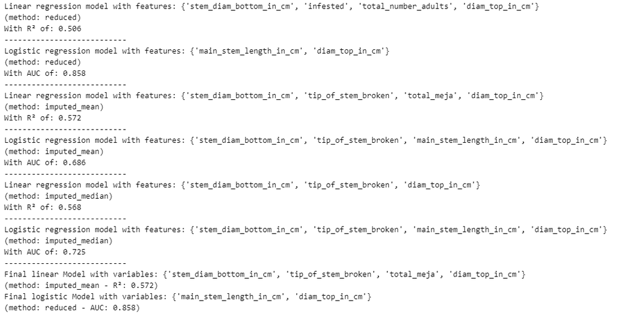

Based on the results we chose the imputed_mean method for our linear regression model. The best performance of the model can be reached using the following features to predict a plants main stem length: 'total_meja', 'stem_diam_bottom_in_cm', 'tip_of_stem_broken', 'diam_top_in_cm'.

For our logistic regression model, we chose the reduced method. The best performance can be reached using the features 'main_stem_length_in_cm', 'diam_top_in_cm' to predict whether a plant is infested or not.

### 2.3 Oversampling

In chapter 2.2 we chose the reduced method for our logistic regression model. Therefore, we have less observations in our remaining dataset. We recognized that the proportion of infested and not infested plants in our dataset was imbalanced, so we used oversampling to compensate the difference between value counts and balance our dataset.

We used random oversampler from imblearn. The confusion matrix showed a higher number of false negatives compared to the prior confusion matrix without using oversampling. As we want to analyze whether weevils are effective as natural control agents, we do not want to miss an actual infested plant and aim to optimize recall. Unfortunately, oversampling did not lead to significant improvements of our model regarding the AUC value.

### 2.4 Adjusting Thresholds

The choice of threshold for binary classification problems is an important decision and can have a significant impact on the performance of the model. Since we needed to categorize our predictions into infested or not infested, we started by setting a threshold of 0.5. We later tried to further optimize our logistic regression model by adjusting the decision threshold to 0.3, 0.4, 0.6 or 0.7.

For 'Not Infested': Higher recall is better for true negatives. The best recall is at a threshold of 0.7.

For 'Infested': Higher recall is better for true positives. The best recall is at a threshold of 0.3.

Considering this, a threshold of 0.5 seemed to be a good compromise, offering a balanced recall for both 'infested' (0.88) and 'not infested' (0.59). This threshold ensures that both 'infested' and 'not infested' are identified with reasonable accuracy, without skewing too heavily towards one at the expense of the other.

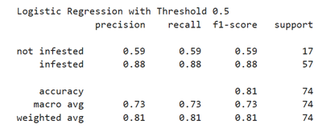

## 3 Results

### 3.1 Linear Regression

```python
linear_regression_model = pickle.load(open('../models/reg_model.sav', 'rb'))
```

```python
intercept_lin = pd.DataFrame({
    "Name": ["Intercept"],
    "Coefficient":[linear_regression_model.intercept_]}
    )

slope_lin = pd.DataFrame({
    "Name": ['total_meja', 'stem_diam_bottom_in_cm', 'tip_of_stem_broken', 'diam_top_in_cm'],
    "Coefficient": linear_regression_model.coef_}
)

table_lin = pd.concat([intercept_lin, slope_lin], ignore_index=True, sort=False)

round(table_lin, 2)
```

|  | Name | Coefficient |
| --- | --- | --- |
| 0 | Intercept | 17.95 |
| 1 | total_meja | 103.90 |
| 2 | stem_diam_bottom_in_cm | -8.43 |
| 3 | tip_of_stem_broken | -0.27 |
| 4 | diam_top_in_cm | -72.27 |

**Evaluation on test set:**

First, we used the r2_score function to calculate R² between the actual values and the predicted values. The R² value is between 0 and 1, where 1 means that the model explains all variation in the dependent variables, and 0 means that the model has no explanatory power beyond predicting the average. An **R² value of 0.57** shows that about 57% of the variations in the actual values can be explained by the model. This indicates that the model has moderate success in explaining the observed variations. However, there is still room for improvement as more than 43% of the variations are not explained by the model.

The Root Mean Squared Error indicates the average size of the absolute deviations between the actual and predicted values. A lower RMSE indicates more accurate predictions. In our case, the **RMSE of 16.11 cm** means that the average deviation between the actual and predicted values is about 16.11 cm. Considering that the minimum main stem length is 2 cm, the maximum main stem length is 135 cm and the standard deviation 24.92 cm, the RMSE of 16.11 can be considered acceptable given the span of the main stem lengths.

### 3.2 Logistic Regression

```python
logistic_regression_model = pickle.load(open('../models/log_model.sav', 'rb'))
```

```python
intercept_log = pd.DataFrame({
    "Name": ["Intercept"],
    "Coefficient":logistic_regression_model.intercept_}
    )

slope_log = pd.DataFrame({
    "Name": ['main_stem_length_in_cm', 'diam_top_in_cm'],
    "Coefficient": logistic_regression_model.coef_[0]}
)

table_log = pd.concat([intercept_log, slope_log], ignore_index=True, sort=False)

round(table_log, 2)
```

|  | Name | Coefficient |
| --- | --- | --- |
| 0 | Intercept | 4.17 |
| 1 | main_stem_length_in_cm | -0.07 |
| 2 | diam_top_in_cm | 3.73 |

**Interpretation of the results:**

- The intercept is approximately 4.17. This is the expected log odds value when all other independent variables are zero. In this case, it's a relatively high positive number, which suggests a high baseline probability of the outcome occurring when the other variables are not in play.
- The negative coefficient for "main_stem_length_in_cm" of -0.07 indicates that as the main stem length increases, the likelihood of the outcome decreases.
- The positive coefficient for "diam_top_in_cm" of 3.73 indicates that as the diameter of the stem tip increases, the likelihood of the outcome significantly increases.

**Evaluation on test set:**

We display a confusion matrix which shows how many instances of each class have been correctly or incorrectly classified.

- True Positives: Correctly classified positive instances, in our case 50.
- True Negatives: Correctly classified negative instances, in our case 10.
- False Positives: Incorrectly classified positive instances (incorrectly identified as positive), in our case 7.
- False Negatives: Incorrectly classified negative instances (incorrectly identified as negative), in our case 7.

We want to optimize recall and aim for a low number of false negatives. In our matrix we can see false negatives are only 7 and we have a high number of correctly predicted instances.

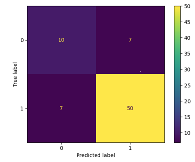

To further evaluate our logistic regression model, we visualized the ROC curve (Receiver Operating Characteristic Curve). Previously, we had set the threshold value to 0.5. The ROC curve provides a visual way to observe changes in our model's classification thresholds that affect the model's performance. We plot the rate of true positives against the rate of false positives for all possible thresholds. The curve shows that our model performs well, because the higher and closer to the perfect classifier the ROC curve is, the better the model performs.

The Area Under the ROC Curve (AUC) is a performance measure which is independent of the exact classification threshold chosen. AUC is between 0 and 1, with higher numbers indicating better performance so our **AUC of 0.86** indicates that our logistic regression model is performing well.

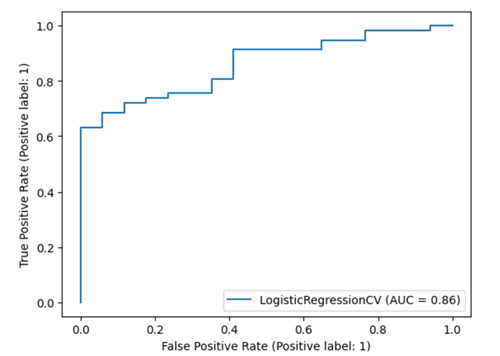

## 4 Discussion and Conclusion

The study on the release and establishment of the weevil Mecinus janthiniformis for biological control of Dalmatian toadflax in Southern California provides valuable insights into the complex interplay between invasive plant species, biological control agents and the environment. Our hypothesis was that the spread of weevil populations contributes to the reduction of Dalmatian toadflax vegetation in the area and reduces the size of the plants.

### 4.1 Achievements

After inspecting the data, we noticed that some rows were missing information. Using imputation, we successfully addressed this problem. Three different methods have been introduced (reduced, imputed_mean and imputed_median) to find the most suitable approach for each of the two models. For a effective and comprehensible way to select the appropriate features for our model we implemented various functions that automatically output the best fitting features based on forward selection using R² as a measure for linear regression and AUC for logistic regression. For both, linear and logistic regression, we performed an extensive evaluation. We assessed our linear regression model using common metrics such as MSE, RMSE and R². For our logistic regression model, we aimed to improve recall. Various options on different decision thresholds have been tested and the final model has been evaluated using ROC and AUC.

### 4.2 Limitations

In the following we want to address the limitations that apply to our model.

1. Potential improvements through complete data: During our analysis we quickly recognized that some interesting predictor variables do have a range of missing values. Although we tried to account for this fact using imputation, a complete data set would likely have led to potential improvements and better model performance.
2. Relation to a specific region: As the data was collected in a specific region in Southern California, the results may only be transferable to other regions to a limited extent. An idea for future work could be to include data from other regions as well.
3. External factors: For the spread and success of weevil Mecinus janthiniformis as natural control agents for the containment of Dalmatian toadflax, external factors such as weather and environmental influences also play a role, which cannot be planned and integrated into the model.
4. Domain knowledge: It would have been better to have more specific domain knowledge during our analysis. Although the data was accurately described in a dictionary by the data collectors, open issues arose for which we ultimately had to make assumptions. For future work clarification on unclear topics could be useful, e.g. number of total plants vs. samples in our dataset.

### 4.3 Analysis of the Results

#### 4.3.1 Linar Regression

In linear regression, the most appropriate method for dealing with missing values was the imputed_mean method, where the mean value was used to fill in the missing values in the respective columns.

The most powerful predictor variables found with forward selection are:

- stem_diam_bottom_in_cm
- diam_top_in_cm
- total_meja
- tip_of_stem_broken

#### 4.3.2 Logistic Regression

For the logistic regression model, we chose the reduced method as it led to the best results. In this method, all rows with missing values were omitted and therefore a reduced data set was used for the model.

The most powerful predictor variables found with forward selection are:

- main_stem_length_in_cm
- diam_top_in_cm

With these variables, our model reaches a AUC score of 0.86. Oversampling or adjusting the decision threshold did not lead to a significant increase in model performance.